# 6.041x - Unit 4: Discrete Random Variables

## Core Concepts:

**Random Variable:** a numerical quantity whose value is determined by the outcome of the probabilistic experiment (e.g. the weight of a randomly selected person)

- Abstract concept of weight: $\mathbf{W}$ (random variable)
- Particular weight of given student: $\mathbf{w}$ (actual number)
- Weight is an object whose value is determined once the outcome of the prob. experiment is known
- Can think of Weight ($W$) as black box/function: $student \to \mathbf{W(student)} \to w$
- Possible for a given probabilistic experiment to have multiple associated random variables (e.g. weight W, height H, etc.)
  - Create new random variable based off other random variables, e.g. $BMI = B = \frac{W}{H^2}$ (still a function of outcomes)
- Random variables are functions mapping $\Omega$ to real numbers (discrete or continuous values)
  - Meaning of $X + Y$: random variable takes value $x + y$, where X takes value x and Y takes value y given some outcome
- Since some of the outcomes of a probabilistic experiment are more likely than others, the associated numerical values of random variables will be more likely than others

**Probability Mass Functions (PMF, Probability Law or Probability Distribution):** description of relative likelihoods for values of random variable

- Define the y-axis of a PMF for random variable X, $p_X(x) = P(X=x) = P(\{\omega \in \Omega\ such\ that\ X(\omega)=x\})$
  - $PMF = f(x)$, where for any x, the PMF specifies the probability that the random variable X takes on this particular value x
- Properties:
  - $p_X(x) \geq 0$ (like any probability)
  - $\sum\limits_{x}p_X(x)=1$

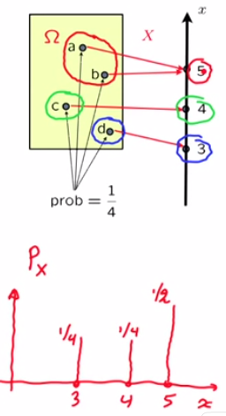

- To calculate PMF:
  - Determine sample space and probability rule (e.g. 2 fair dice rolls $\to$ 4x4 grid where each outcome has probability $\frac{1}{16}$
  - Determine random variable (e.g. Z = sum of 2 dice rolls)
  - Calculate Z for all outcomes
  - Plot $p_Z(z)$ for all z

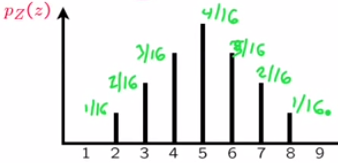

**Discrete Random Variable Example 1: Bernoulli with Parameter $\mathbf{p \in [0,1]}$**: models trial resulting in success/failure (e.g. coin, yes/no, 0 or 1 etc.)

**Indicator Variables:** Bernoulli random variables that allow us to translate manipulations of events into manipulations of random variables

- E.g. sample space is split into $A$ and $A^c$.
  - For indicator variable $I_A \to P_{I_A}(1) = P(I_A = 1) = P(A)$

**Discrete Random Variable Example 2: Uniform with Parameters $\mathbf{a,b \in \mathbb{Z}}$ (integers):** a "setup" or "ignorant" model with equal probabilities for all random variable values

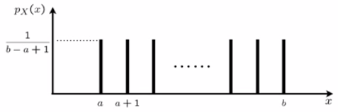

- Here, the outcome of the experiment is the same as the value of the random variable $\to X(\omega) = \omega$
- Model of complete igorance, e.g. looking at digital clock and guessing the second value (a = 0, b = 59)

**Discrete Random Variable Example 3: Binomial with Parameters $\mathbf{n}$ and $\mathbf{p \in [0,1]}$**: models experiment of $n$ trials with $P(success) = p$

- E.g. $n$ tosses of coin with $P(heads) = p$
  - Sample space $\Omega$: set of sequences of H & T of length n $\to$ HH, HT, TH, TT for n = 2
  - Random variable X: number of heads observed
  - Models fixed number of identical and independent trials where trial outcomes are success or failure with probabilities $p$ and $1-p$ respectively
- Y-Axis of PMF is same as previous binomial formula: $p_X(k) = \binom{n}{k}p^k(1-p)^{n-k}$ for $k = 0,1,...,n$

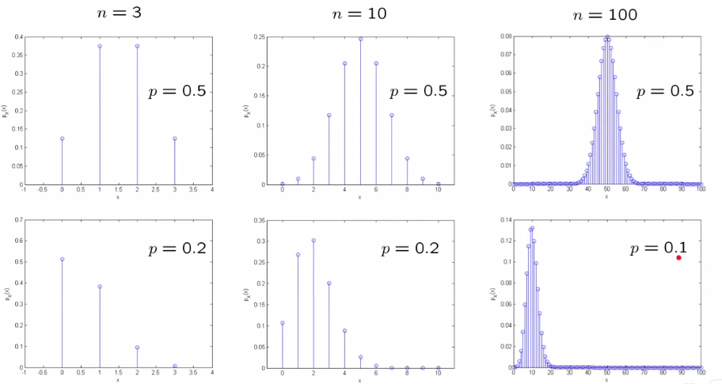

**Discrete Random Variable Example 4: Geometric with Parameter $\mathbf{0 < p \leq 1}$**: models experiment infinitely many independent success/failure trials with $P(success) = p$

- Random variable $X$: number of trials until first success
- E.g. flip a coin forever:
  - Sample space is set of infinite sequences of H & T
  - Random variable $X$: number of flips until first heads
- If k is number of trials until specified event: $p_X(k) = P(X = k) = P(FFF...FS) = P(F)^{k-1}P(S) = (1-p)^{k-1}p,\ where\ k = 1, 2, 3...$
- Used to model waiting times, number of trials until an event, etc.
- Definitely related to survival analysis

**Expectation:** one form of summary of a random variable (the average, mean, etc.) $\to$ the average outcome in a large number of independent trials

- E.g.: X is random variable of "gain" in a trial. $p_X(1) = \frac{2}{10}, \ \ p_X(2) = \frac{5}{10}, \ \ p_X(3) = \frac{3}{10}$
  - Can say the expected (average) gain is $\frac{1*200 + 2*500 + 3*300}{1000} = 1p_X(1) + 2p_X(2) + 3p_X(3)$
- Generally, $\mathbf{E[X] = \sum\limits_{x}xp_X(x)}$
- Assumption: for infinite sums, $E[X] = \sum\limits_{x}|x|p_X(x)<\infty$ (infinite sum well defined)
- Average of a population: e.g. n students, weight of i'th student is $x_i$
  - If all equally likely to be chosen and $x_i$'s are distinct: $E[X] = \sum\limits_{i}x_i\frac{1}{n} = \frac{1}{n}\sum\limits_{i}x_i$
- Properties:
  - If for all $\omega, \ X(\omega) \geq 0$, that is, $X \geq 0$, then $E[X] \geq 0$
  - If $a \leq X \leq b$, then $a \leq E[X] \leq b$
  - For a constant c, $E[c] = c$

**Expectation of Bernoulli Random Variable:**

- Recall $p_X(1) = p$ and $p_X(0) = 1-p$
- As such, $E[x] = 1p + 0(1-p) = p \to \mathbf{E[X] = p}$
  - If $X$ is indicator variable $X = I_A$ (i.e. $X = 1$ if A occurs, $X=0$ otherwise, such that $p = P(A)$) $\to E[I_A] = P(A)$

**Expectation of Uniform Random Variable:**

- E.g. uniform on [0,n] (a = 0, b = n): $p_X(x) = \frac{1}{n+1}$
  - $E[X] = \frac{1}{n+1}(0 + 1 + 2 + ... + n) = \frac{1}{n+1}\frac{n(n+1)}{2} = \frac{n}{2}$
- Generally, $E[X] = \frac{a+b}{2} \to$ the midpoint! AKA the "balance point"

**Expected Vale Rule for Calculating $\mathbf{E[g(X)]}$:**

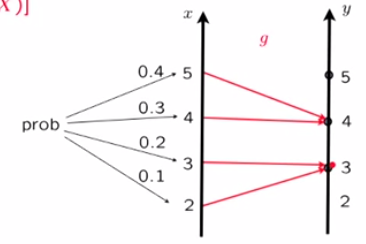

- Let $X$ be a random variable and $Y = g(X) \to$ 2 ways to calculate $E[Y]$:
  1. Averaging over y: $E[Y] = \sum\limits_{y}yp_Y(y)$
     - $E[Y] = 3*(0.1 + 0.2) + 4 * (0.3 + 0.4)$
  2. Averaging over x (**Expected Value Rule**): $\mathbf{E[Y] = E[g(X)] = \sum\limits_{x}g(x)p_X(x)}$
     - $E[Y] = 3*0.1 + 3*0.2 + 4*0.3 + *0.4$
- Number 2 has the advantage that we don't have to find the pmf of new variable ($p_Y(y)$ not needed)
- Application:
  - $E[X^2] = \sum\limits_{x}x^2p_X(x) \to$ here, $g(x) = x^2$
  - Note that $E[g(x)] \neq g(E[X])$, e.g. here $E[X^2] \neq (E[X])^2$
- **Linearity of Expectations:**
  - $E[aX + b] = aE[X]+b$
  - Can derive with Expected Value Rule
- **Variance:** quantifies the spread of the distribution of a random variable
  - "Distance from the mean $\mu$": Variance ~ $X - \mu$ (which is a random variable in itself)
    - Can calculate $E[X-\mu] = E[x] - \mu = 0$
  - More mathematically sound $\to$ the squared distance from the mean: $\mathbf{var(X) = E[(X - \mu)^2]}$ $\ \ $(note: $var(X) \geq 0$)
  - Calculate using Expected Value Rule $E[g(X)] = \sum\limits_{x}g(x)p_X(x)$ with $g(x) = (x - \mu)^2 \to \mathbf{var(X) = E[g(X)] = \sum\limits_{x}(x-\mu)^2p_X(x)}$
  - Properties:
    - Adding a constant to a random variable does not change the variance: $var(X + b) = var(X) \to$ just shifts PMF left or right
    - Multiplying random variable by constant does the following to variance: $var(aX) = a^2var(X)$
  - Variance can be calculated just with means with handy formula: $\mathbf{var(X) = E[X^2] - (E[X])^2}$
    - Foil out $E[(X - \mu^2)]$ recalling $\mu = E[X]$ to see this is true
- **Standard Deviation:** more intuitive measure of spread with same units as random variable
  - Note that variance has units $[m^2]$ if random variable has units $[X]$.
    - Take square root of variance: $\sigma = \sqrt{var(X)}$

**Variance of Bernoulli Random Variable:**

- Recall $p_X(1) = p, \ p_X(0) = 1-p$, and $E[X] = p$ for Bernoulli random variable
- Two ways to calculate variance of Bernoulli:
  1. $var(X) = \sum\limits_{x}(x-\mu)^2p_X(x)$
     - $var(X) = (1-p)^2p + (0 - p)^2(1-p) = p(1-p)$
  2. $var(X) = E[X^2] - (E[X])^2$
     - Note that here, $X^2 = X$ (Bernoulli special case)
     - As such, $var(X) = E[X] - (E[X])^2 = p - p^2 = p(1-p)$
- So $\mathbf{var(X) = p(1-p)}$ for Bernoulli -- zero variance at p = 0 and p = 1, max variance at p = 0.5

**Variance of Uniform Random Variable:**

- Use alternative formula (easiest math):
  - $var(X) = E[X^2] - (E[X])^2 = \frac{1}{n+1}(0^2 + 1^2 + 2^2+...+n^2) - (\frac{n}{2})^2$
  - Use formula for sum in that expression, get $var(X) = \frac{1}{12}n(n+2)$
    - Note that instead of 0 to n, we can say a to b (as long as n = b - a) and variance does not change! Just a PMF shift.
- As such, make substitution: $\mathbf{var(X) = \frac{1}{12}(b-a)(b-a+2)}$

**Conditional PMF and Expectation:**

- Up to now:
  - $p_X(x) = P(X=x)$
  - $\sum\limits_{x}p_X(x) = 1$
  - $E[X] = \sum\limits_{x}xp_X(x)$
  - Expected Value Rule: $E[g(X)] = \sum\limits_{x}g(x)p_X(x)$
  - $var(X) = \sum\limits_{x}(x-E[X])^2p_X(x) = E[X^2] - (E[X])^2$
- Conditioning on some event A (event A is known to have occured and $P(A) > 0$)
  - $p_{X|A}(x) = P(X = x|A)$
  - $\sum\limits_{x}p_{X|A}(x) = 1$
  - $E[X|A] = \sum\limits_{x}xp_{X|A}(x)$
  - Expected Value Rule: $E[g(X)|A] = \sum\limits_{x}g(x)p_{X|A}(x)$
  - $var(X|A) = \sum\limits_{x}(x-E[X|A])^2p_{X|A}(x) = E[X^2|A] - (E[X|A])^2$

**Total Expectation Theorem**:

- Recall Total Probability Theorem: $P(B) = P(A_1)P(B|A_1)+...+P(A_n)P(B|A_n)$
- If $B = \{X = x\}$:
  - $p_X(x) = P(A_1)p_{X|A_1}(x)+...+P(A_n)p_{X|A_n}(x) \to$ Total Probability Theorem translated to PMF notation
- Multiplying both sides by $\sum\limits_{x}x$, get:
  - $\mathbf{E[X] = P(A_1)E[X|A_1]+...+P(A_n)E[X|A_n]}$
    - Allows dividing PMF into sections $A_1, A_2,...,A_n$ and "divide and conquer" to find $E[X]$

**Conditioning a Geometric Random Variable:**

- Recall Geometric Random Variable properties:
  - $P(H) = p$
  - Random variable $X$: number of trials until first heads

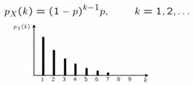

- "Memorylessness": number of remaining tosses, conditioned on T in first toss, is still geometric with parameter $p$
  - $p_{X-n|X>n}(k) = P(X-n=k|X>n) = P(T_2T_3T_4....H_{k+1}|T_1) = P(T_2T_3T_4....H_{k+1}) = p_X(k)$
  - Bottom line: $\mathbf{p_X(k) = p_{X-n|X>n}(k)}$, and as such, $\mathbf{E[X-n|X>n] = E[X]}$
- Useful for calculating expectation of geometric distribution:
  - $E[X] = \sum\limits_{k=1}^\infty k p_X(k) = \sum\limits_{k=1}^\infty k (1-p)^{k-1}p$ is hard to compute!
  - Instead: $E[X] = 1 + E[X-1]$ (by linearity of expectations)
    - $E[X] = 1 + E[X-1] = 1 + pE[X-1|X=1] + (1-p)E[X-1|X>1]$ by Total Expectation Theorem
    - $E[X] = 1 + 0 + (1-p)E[X]$
  - As such, $\mathbf{E[X] = \frac{1}{p}}$ for Geometric Random Variable X

**Multiple Discrete Random Variables and Joint PMFs:**

- Say we have $X:p_X$ and $Y:p_Y$, two individual random variables and their marginal (individual) PMFs
  - Cannot say anything about relationship between $X$ and $Y$ (e.g. $P(X = Y) = ?$)
- Joint PMF: $p_{X,Y}(x,y) = P(X = x\ and\ Y = y)$
  - Function of 2 arguments $f(x,y)$
  - $\sum\limits_{x}\sum\limits_{y}p_{X,Y}(x,y) = 1$

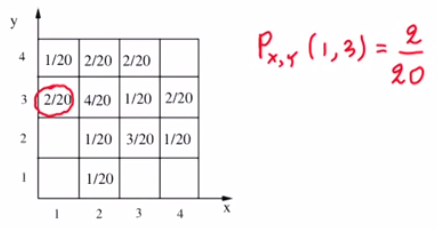

- Can deduce marginal (individual) PMFs from joint PMF: add probability rows/columns accordingly
  - $p_X(x) = \sum\limits_{y}p_{X,Y}(x,y)$ and $p_Y(y) = \sum\limits_{x}p_{X,Y}(x,y)$
- With joint PMF, we see that $P(X = Y)$ is sum of diagonal probabilities x = y!
- Can have more than 2 variables:
  - $p_{X,Y,Z}(x,y,z) = P(X = x\ and\ Y = y\ and\ Z = z)$
  - $\sum\limits_{x}\sum\limits_{y}\sum\limits_{z}p_{X,Y,Y}(x,y,z) = 1$
  - $p_X(x) = \sum\limits_{y}\sum\limits_{z}p_{X,Y,Y}(x,y,z)$
  - $p_{X,Y}(x,y) = \sum\limits_{z}p_{X,Y,Y}(x,y,z)$
- Say we have $Z = g(X,Y)$:
  - $PMF = p_Z(z) = P(Z=z) = P(g(x,y) = z) = \sum\limits_{(x,y):g(x,y)=z}p_{X,Y}(x,y)$
- Expected Value Rule for Joint PMFs: $\mathbf{E[g(X,Y)] = \sum\limits_{x}\sum\limits_{y}g(x,y)p_{X,Y}(x,y)}$

**Linearity of Expectations for Multiple Random Variables:**

- $\mathbf{E[X + Y] = E[X] + E[Y]}$
  - Proven by defining $g(x,y) = x + y$ and using Expected Value Rule for Joint PMFs
  - Extends to $n$ random variables
- Note that $E[2X+3Y-Z] = 2E[X] + 3E[Y] - E[Z]$

**Expectation of Binomial Random Variable:**

- Recall Binomial random variable with parameters $n$ and $p$:
  - $X$: number of successes ($P(success) = p)$ and $n$ is number of independent trials
- Expectation: $E[X] = \sum\limits_{k=0}^{n}kp_X(k) = \sum\limits_{k=0}^{n}k\binom{n}{k}p^k(1-p)^{n-k} \to$ hard to calculate!
  - Break $X$ into $X = X_1 + X_2+...+X_n$, where $X_i = 1$ if $i$'th trial is success, $X_i = 0$ otherwise
  - Now, $E[X] = E[X_1]+...+E[X_n]$ by linearity of expecations
  - Each indicator variable $X_i$ is Bernoulli variable with $E[X_i] = p$
- Therefore, $\mathbf{E[X] = np}$ for Binomial random variable

**Conditional PMFs Based on Other Random Variables (Joint PMFs):** $A = \{Y=y\}$

- Already seen conditioning PMF of random variable $X$ on event A: $p_{X|A}(x|A) = P(X=x|A)$
- What if A is event that some other random variable takes a value? $\to A = \{Y=y\}$
  - $p_{X|Y}(x|y) = P(X=x|Y=y) = \frac{P(X=x\ \cap\ Y=y)}{P(Y=y)}$
- This leads to definition of conditioning on another random variable: $\mathbf{p_{X|Y}(x|y) = \frac{p_{X|Y}(x,y)}{p_Y(y)}}$, defined for $y$ where $p_Y(y) > 0$
  - Note that $\sum\limits_{x}P_{X|Y}(x|y) = 1$
  - Also leads to $p_{X|Y}(x,y) = p_Y(y)p_{X|Y}(x|y)$ and similarly, $p_{X|Y}(x,y) = p_X(x)p_{Y|X}(y|x)$
- Similar forms for more than 2 random variables (can condition on one or more random variables)
- Previously:
  - Multiplication Rule: $P(A \cap B \cap C) = P(A)P(B|A)P(C|A \cap B)$
  - Conditional Expecation: $E[X|A] = \sum\limits_{x}xp_{X|A}(x)$
  - Expected Value Rule: $E[g(X)|A] = \sum\limits_{x}g(x)p_{X|A}(x)$
  - Total Probability Theorem: $p_X(x) = P(A_1)p_{X|A_1}(x)+...+P(A_n)p_{X|A_n}(x)$
    - Given that $\Omega$ partitioned into $A_1, A_2,...,A_n$
  - Total Expectation Theorem: $E[X] = \sum\limits_{i}P(A_i)E[X|A_i]$
    - Given that $\Omega$ partitioned into $A_1, A_2,...,A_n$
- Conditioning on $A = \{Y=y\}$
  - Multiplication Rule: if $A = \{X=x\}$, $B = \{Y=y\}$, $C = \{Z=z\} \to p_{X,Y,Z}(x,y,z) = p_X(x) p_{Y|X}(y|x)p_{Z|X,Y}(z|x,y)$
  - Conditional Expectation: $E[X|Y=y] = \sum\limits_{x}xp_{X|Y}(x,y)$
  - Expected Value Rule: $E[g(X)|Y=y] = \sum\limits_{x}g(x)p_{X|Y}(x|y)$
  - Total Probability Theorem: $p_X(x) = \sum\limits_{y}p_Y(y)p_{X|Y}(x|y)$
    - Given that $\Omega$ partitioned into $A_1, A_2,...,A_n$, with $Y = \{y_1,...,y_n\}$ and $A_i = \{Y=y_i\}$
  - Total Expectation Theorem: $E[X] = \sum\limits_{y}p_Y(y)E[X|Y=y]$
    - Given that $\Omega$ partitioned into $A_1, A_2,...,A_n$, with $Y = \{y_1,...,y_n\}$ and $A_i = \{Y=y_i\}$

**Independence of Random Variables:**

- Recall independence of 2 events: $P(A \cap B) = P(A)P(B)$ and $P(A|B) = P(A)$
- Independence of a Random Variable and some event A: $P(X = x \cap A) = P(X=x)P(A)$ for all x
  - PMF of X does not change given A: $p_{X|A}(x) = p_X(x)$ for all x, and by symmetry $P(A|X=x) = P(A)$ for all x
- For independence of Two Random Variables: $P(X = x \cap Y = y) = P(X=x) P(Y=y)$ for all $x, y$
  - Formally, $\mathbf{p_{X,Y}(x,y) = p_X(x)p_Y(y)}$ for all $x,y$ if Random Variables are independent
  - Can say $p_{X|Y}(x|y) = p_X(x)$ and $p_{Y|X}(y|x) = p_Y(y)$
  - Extends to $n$ random variables

**Independence and Expectation:**

- If $X$ and $Y$ are independent: $\mathbf{E[XY] = E[X]E[Y]}$
- Additionally, if $g(X)$ and $h(Y)$ are also independent: $E[g(X)h(Y)] = E[g(X)]E[h(Y)]$
  - Can prove these with Expected Value Rule for Joint PMFs

**Independence and Variance:**

- Recall that $var(aX) = a^2var(X)$ and $var(X+a) = var(X)$, and these are always true
- If $X$ and $Y$ independent, $\mathbf{var(X+Y) = var(X) + var(Y)} \to$ NOT true generally

**Variance of Binomial Random Variable:** $X$: number of successes in $n$ independent trials with $P(success) = p$

- Break $X$ into $X = X_1 + X_2+...+X_n$, where $X_i = 1$ if $i$'th trial is success, $X_i = 0$ otherwise
- Now, $var(X) = var(X_1)+...+var(X_n) = n*var(X_i)$ by independence of indicator variables $X_i$
- Each indicator variable $X_i$ is Bernoulli variable with $var(X_i) = p(1=p)$
- As such, $\mathbf{var(X) = np(1-p)}$

## Additional Theoretical Material and Summary:

**Functions:**

- Definition of function: 2 sets, A and B. Function is a rule that for every element in A, there is a corresponding element in B.
  - Multiple elements of A can map to the same element in B
  - Each element in A only maps to a single element in B
- Formally, set of pairs $(x,y)$ with $x \in A$ and $y \in B$ where each $x$ appears in exactly one pair
  - Example for square function: $\{(x, x^2) \in \mathbb{R}^2 | x \in \mathbb{R}\}$
  - Equivalently, function $f: \mathbb{R} \to \mathbb{R}$ defined by $f(x) = x^2$, informally "the function $x^2$"

**Variance of Geometric PDF:**

- Let $X$ be a geometric random variable with parameter $p \to$ e.g. number of coin flips that it takes to obtain first heads and $P(heads) = p$
- Recall memorylessness: Given $X>1$, then $X - 1$ has same geometric PMF as unconditional PMF of $X$
  - Can also say that given $X>1$, then $X$ has same geometric PMF as unconditional PMF of $X + 1$ (just added 1)
- Because of this, $E[X|X>1] = 1 + E[X]$ and $E[X^2|X>1] = E[(X+1)^2]$
- Using Total Expectation Theorem with fact that $E[X] = \frac{1}{p}$ for geometric r.v.s:  
  \begin{align} E[X^2] &= P(X=1)E[X^2|X=1] + P(X>1)E[X^2|X>1] \ &= p \bullet 1 + (1-p) \bullet (E[X^2] + 2E[X] + 1) \ &= p + (1-p)(E[X^2] + \frac{2}{p} + 1) \end{align}
  - Solve for $E[X^2] = \frac{2 - p}{p^2}$
- Finally, use formula $var(X) = E[X^2] - (E[X])^2$ to get $\mathbf{var(X)_{geo} = \frac{1 - p}{p^2}}$

**Inclusion Exclusion Formula:**

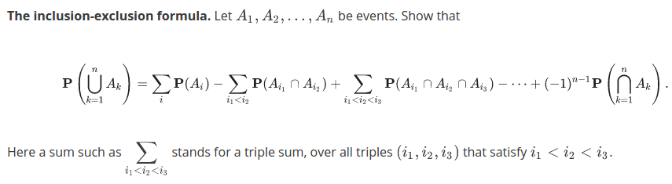

- Recall first inclusion exclusion formula for 2 events: $P(A \cup B) = P(A) + P(B) - P(A \cap B)$
- Can generalize to 3 events: $P(A \cup B \cup C) = P(A) + P(B) + P(C) - (P(A \cap B) + P(A \cap C) + P(B \cap C)) + P(A \cap B \cap C)$
- Want to generalize to $n$ joint events using Indicator Functions:
  - For any event $A_i$, give indicator function $X_i$ where $X_i = 1$ if event is in set $A_i$ and $0$ otherwise
  - Note that for $A_u^c$, get $1 - X_i$ (opposite results for indicator variable)
  - For $A_i \cap A_j$, indicator variable is $X_i X_j$, so equal to 1 only if event is in both sets
  - For $A_i^c \cap A_j^c$, indicator variable is $(1-X_i)(1-X_j)$
  - For $A_i \cup A_j$, from DeMorgan's laws, know this is $(A_i^c \cap A_j^c)^c \to$ indicator variable is $1 - (1-X_i)(1-X_j)$
- Can extend these formulas to any number of sets
- Recall that $P(event) = E[indicator\ of\ event]$ \begin{align} P(A \cup B \cup C) &= E[1 - (1 - A)(1 - B)(1 - C)] \ &= E[1 - 1 + A + B + C - AB - BC - AC + ABC] \ &= E[A + B + C - AB - BC - AC + ABC] \ &= P(A) + P(B) + P(C) - P(A \cap B) - P(B \cap C) - P(A \cap C) + P(A \cap B \cap C) \end{align}
  - This matches above formula of generalizing to three events! We extend this idea to any number of subsets, completing the proof.

**Independence of Events vs. Random Variables:**

- Events A and B
  - Indicator variables $X = I_A$ where $X = 1$ if $A$ occurs and $0$ otherwise, and similarly $Y = I_B$

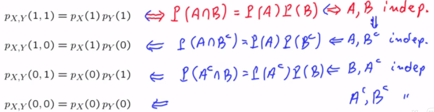

- As such, independence of events A and B rely on independence of random variables X and Y and vice versa

**Summary:**

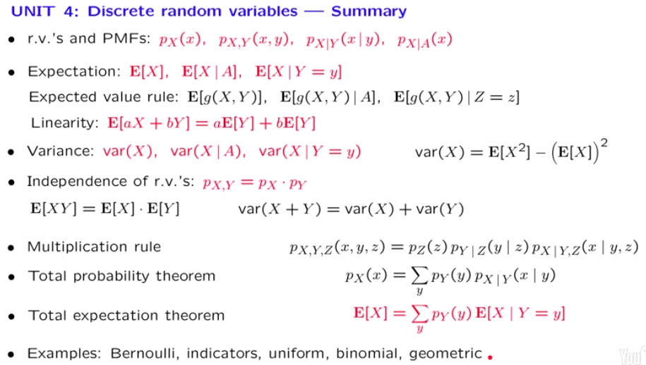

## Lecture 5, 6, and 7 Exercises:

Currently unavailable in archived course.

## Solved Problems:

**#1: PMF of a function of a random variable:**

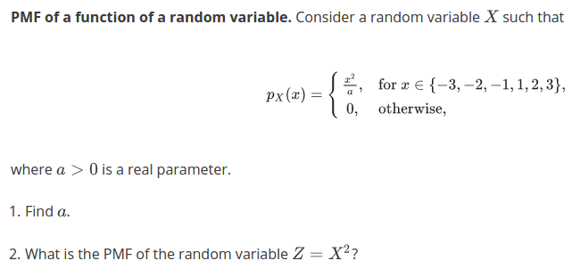

1. Because $\sum\limits_{x}p_X(x) = 1$, can solve for $a$:
   - $2\frac{9}{a} + 2\frac{4}{a} + 2\frac{1}{a} = 1 \to a = 28$
2. Z is new random variable $\to p_Z(z) = ?$
   - Possible vales of Z: $Z = \{9, 4, 1\}$
   - Z takes on value of 1 when X = 1 and -1: $\{Z = 1\} = \{X = 1\} \cup \{X = -1\} = \frac{1}{a} + \frac{1}{a} = \frac{2}{a}$
   - Similar argument for 4 and 9: $p_Z(4) = \frac{8}{a}$ and $p_Z(9) = \frac{18}{a}$ where again, $a = 28$
   - Specify that $p_Z(z) = 0$ otherwise

**#2: Sampling people on buses. Four buses carrying 148 job-seeking MIT students arrive at a job convention. The buses carry 40, 33, 25, and 50 students, respectively. One of the students is randomly selected. Let X denote the number of students that were on the bus carrying this randomly selected student. One of the 4 bus drivers is also randomly selected. Let Y denote the number of students on his bus.**

**1. Which of E[X] or E[Y] do you think is larger? Give your reasoning in words.**

**2. Compute E[X] and E[Y].**

1. Take to extreme: 2 busses, one with 1, one with 1000. E[X] here is greater, as overwhelmingly likely (1000/1001) to select student from large bus. Same applies here.
2. - Find PMF of X: $p_X(40) = \frac{40}{148}$, etc $\to$ PMF favored towards larger values
   - Find PMF of Y: $p_Y(40) = \frac{1}{4}$, etc. $\to$ PMF equal at all Y = y at 1/4
   - $E[X] = \sum\limits_{x}xp_X(x) = 39$
   - $E[Y] = \sum\limits_{y}yp_Y(y) = 37$

**#3: From tail probabilities to expectations:**

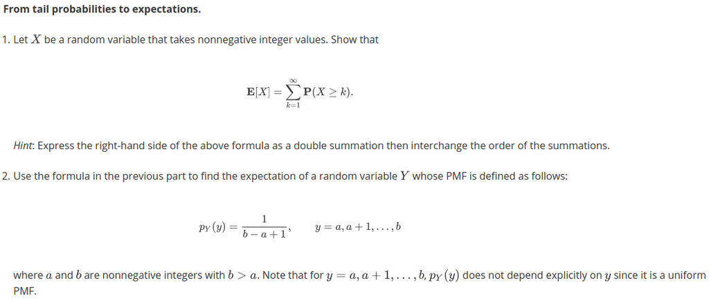

# 1. $X: $ non negative integer values

- $E[X] = \sum\limits_{k = -\infty}^\infty k p_X(k) = \sum\limits_{k = 1}^\infty k p_X(k)$
- $\sum\limits_{k = 1}^\infty P(X \geq k) = \sum\limits_{k = 1}^\infty \sum\limits_{i = k}^\infty p_X(i) = \sum\limits_{i = 1}^\infty \sum\limits_{k = 1}^i p_X(i) \to$ sneaky exchange of summations!

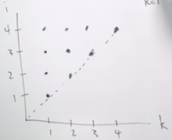

- $\sum\limits_{i = 1}^\infty \sum\limits_{k = 1}^i p_X(i) = \sum\limits_{i = 1}^\infty i p_X(i) \to$ this is $E[X]$

# 2. $b \geq a \geq 0 \to$ a and b are integers, so the above formula applies

- $P(Y \geq k) = ?$
  - When $k \leq a \to P(Y \geq k) = 1$
  - When $k > b \to P(Y \geq k) = 0$
  - When $a < k \leq b \to P(Y \geq k) = \frac{b - k + 1}{b - a + 1}$
- $E[Y] = \sum\limits_{k = 1}^\infty P(Y \geq k) = \sum\limits_{k = 1}^a 1 + \sum\limits_{k = a+1}^b \frac{b - k + 1}{b - a + 1} + \sum\limits_{k = b+1}^\infty 0 = a + \frac{b - a}{2} = \frac{b + a}{2}$
  - This is what we expect for a uniform random variable (expectation is the midpoint)

**#4: Coupon collector problem. A particular professor is known for his arbitrary grading policies. Each paper receives a grade from the set {A,A−,B+,B,B−,C+}, with equal probability, independently of other papers. How many papers do you expect to hand in before you receive each possible grade at least once?**

**#5: Conditioning example:**

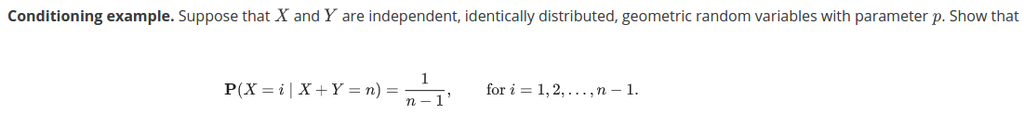

- Here, we condition a geometric distribution on another independent geometric distribution and arrive at a uniform PMF (dependent only on the sum of the outcomes of the distributions). To make this intuitive, imagine two friends flipping coins. The first takes only 1 flip to get heads (X = 1), and the second takes 9 flips (Y = 9). This means n = 10. Because X = 1 is relatively likely and Y = 9 is relatively unlikely, they "cancel" the effect of one another. So as long as the two friends sum to 10, the probability that it took the first friend i flips to get heads is uniform on $i = 1, 2,..., n-1$
- Recall for geometric distribution (number of indpendent trials until success occurs): $p_X(k) = (1 - p)^{k - 1}p$
- Conditioning the expression: $P(X = i | X + Y = n) = \frac{P(X = i) \cap P(X + Y = n)}{P(X + Y = n)}$
- Numerator: note independence of X and Y:

\begin{align} P(X = i) \cap P(X + Y = n) &= P(X = i) \cap P(Y = n - i) \\ &= P(X=i) \bullet P(Y = n-i) \\ &= (1 - p)^{i - 1}p \bullet (1 - p)^{n - i - 1}p \\ &= (1 - p)^{n - 2}p^2 \end{align}

- Denominator: use Total Probability Theorem  
  \begin{align} P(X + Y = n) &= \sum\limits*{k = 1}^{n - 1}P(X = k)P(X + Y = n | X = k) \ &= \sum\limits*{k = 1}^{n - 1}(1 - p)^{k - 1}p P(Y = n - k) \ &= \sum\limits*{k = 1}^{n - 1}(1 - p)^{k - 1}p (1 - p)^{n - k - 1}p \ &= \sum\limits*{k = 1}^{n - 1}(1 - p)^{n - 2}p^2 \end{align}
  - Note: removed conditioning because X and Y are independent
  - Because sum does not depend on $k$, just making copies: $\sum\limits_{k = 1}^{n - 1}(1 - p)^{n - 2}p^2 = (n-1)(1 - p)^{n - 2}p^2$
- Finally, $P(X = i | X + Y = n) = \frac{1}{n-1}$ cancelling everything out

**#6: Joint PMF Drill 1:**

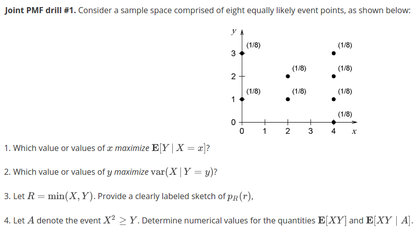

**#7: Joint PMF Drill 2:**

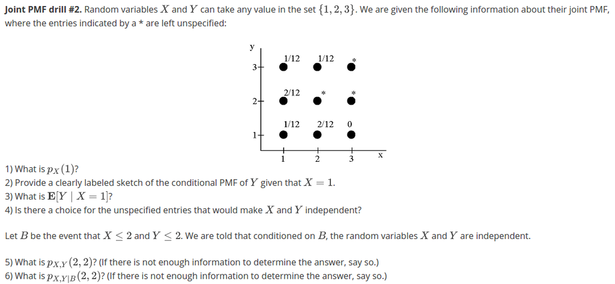

1. $p_X(1) = \frac{1}{12} + \frac{2}{12} + \frac{1}{12} = \frac{1}{3}$
2. $p_{Y|X}(1|X=1) = \frac{1}{4},\ \ p_{Y|X}(2|X=1) = \frac{2}{4}, \ \ p_{Y|X}(3|X=1) = \frac{1}{4} \to$ remember to renormalize in conditional universe
3. $E[Y|X=1] = 2$ (center of mass shortcut)
4. If independent, info about X should not change info about Y. Impossible to have this here, because if $X=3$, you "find out" that $Y \neq 1$
5. Need X and Y to be independent. Need relative frequencies to be equal when Y = 2 and Y = 1. When X = 1, ratio is $\frac{2/12}{1/12}$, so need $p_{X,Y}(2,2) = \frac{4}{12}$ to maintain this ratio.
6. Now have $p_{X,Y}(2,2|B) = \frac{4}{9}$ (renormalize remaining options when conditioned on B)

**#8: Joint PMF Drill 3:**

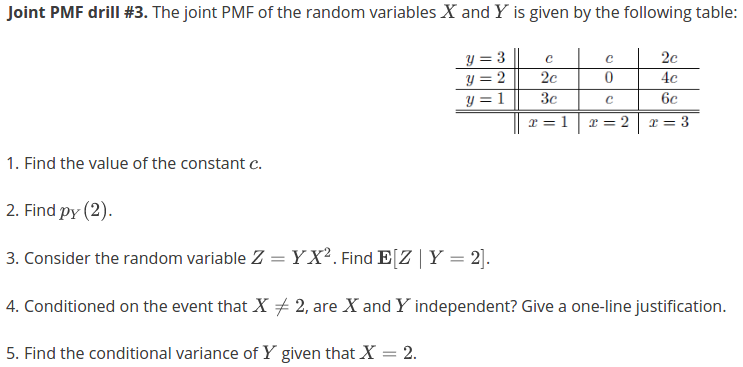

1. For $\sum\limits_{x = 1}^{3}\sum\limits_{y = 1}^{3}p_{X,Y}(x,y) = 1$, need $c = \frac{1}{20}$
2. Sum row $y = 2 \to p_Y(2) = \frac{3}{10}$
3. $E[Z|Y=2] = E[2X^2|Y=2] = 2E[X^2|Y=2]$
   - Conditioning PMF on Y = 2: $p_{X|Y}(X|2) = \frac{p_{X,Y}(X,2)}{p_Y(2)}$
     - $p_{X|Y}(1,2) = \frac{1}{3}$ and $p_{X|Y}(3,2) = \frac{2}{3}$
   - $2E[X^2|Y=2] = 2(1^2 \bullet \frac{1}{3} + 3^2 \bullet \frac{2}{3}) = \frac{38}{3}$
4. Yes. In this conditional universe, knowing X does not tell you anything about Y and v.v., so X and Y are conditionally independent on $X \neq 2$
5. $var(Y|X=2) = E[Y^2|X=2] - (E[Y|X=2])^2$
   - Here, $E[Y|X = 2] = 2$ (midpoint)
   - Additionally, $E[Y^2|X = 2] = 1^2 \bullet \frac{1}{2} + 3^2 \bullet \frac{1}{2} = 5$
   - Therefore, $var(Y|X=2) = 5 - 2^2 = 1$

**#9:Indicator variables: the number of inversions. There are n persons, numbered 1 to n. Each person i is assigned a seat number Xi. The seat numbers are distinct integers in the range 1,…,n. We assume that the seating is “completely random", that is, the sequence (X1,…,Xn) is a permutation of the numbers 1,…,n, and all permutations are equally likely.**

**For any i and j, with 1 ≤ i < j ≤ n, we say that we have an inversion if Xi>Xj. Let N be the number of inversions. Find E[N].**

- Inversion if person with lower index/label has higher seat number.
- Counting approach: $\sum\limits_{\sigma} \frac{1}{n!} \bullet num\ inversions\ for\ perm\ \sigma \to$ this is hard and computationally intensive!
- Indicator variable $V_{i,j} = 1$ if $X_i > X_j$ and $V_{i,j} = 0$ otherwise
  - Now, $N = \sum\limits_{i<j}V_{i,j}$
  - Additionally, $E[N] = E[\sum\limits_{i<j}V_{i,j}] = \sum\limits_{i<j}E[V_{i,j}] = \sum\limits_{i<j}P(X_i > X_j)$ using linearity of expectations and definition of indicator variable
    - Tricky part: because uniformly random permutation, $P(X_i > X_j) = P(X_i < X_j) = \frac{1}{2}$
- So know $E[N] = \frac{1}{2}\{i,j:i<j\}$
- Number of pairings where $i \neq j$ is $n(n-1)$. Divide by 2 because for all pairs e.g. {1,3}, there is a pair {3,1}.
- As such, $E[N] = \frac{1}{2} \frac{n(n-1)}{2} = \frac{1}{4}n(n-1)$

**#8: Indicator variables: the problem of joint lives. Consider 2m persons forming m couples who live together at a given time. Suppose that at some later time, the probability of each person being alive is p, independently of other persons. At that later time, let A be the number of persons that are alive and let S be the number of couples in which both partners are alive. For any number of total surviving persons a, find E[S∣A=a].**

- Define 2 indicator variables:
  - $X_i = 1$ if first partner in couple alive, $X_i = 0$ otherwise
  - $Y_i = 1$ if second partner in couple alive, $Y_i = 0$ otherwise
- Define $Z_i = X_iY_i$, such that $Z_i = 1$ if both couples still alive, $Z_i = 0$ otherwise
  - Now, $S = \sum\limits_{i = 1}^{m}Z_i = \sum\limits_{i = 1}^{m}X_iY_i$
- $E[S|A=a] = E[\sum\limits_{i = 1}^{m}X_iY_i|A=a] = \sum\limits_{i = 1}^{m}E[X_iY_i|A=a]$ using linearity of expectations

\begin{align} E[S|A=a] &= \sum\limits_{i = 1}^{m}E[X_iY_i|A=a] \\ &=m \bullet E[X_1,Y_1|A=a]\ (1\ being\ arbitrary) \\ &=m \bullet P(X_1Y_1 = 1|A=a)\ (Z_1\ is\ indicator\ variable) \\ &=m \bullet P(X_1 = 1|A=a)P(Y_1 = 1|X_1 = 1 \cap A=a)\ (multiplication\ rule) \\ &=m \bullet \frac{a}{2m} \frac{(a-1)}{(2m-1)} \\ &=\frac{a}{2}\frac{(a-1)}{(2m-1)} \end{align}

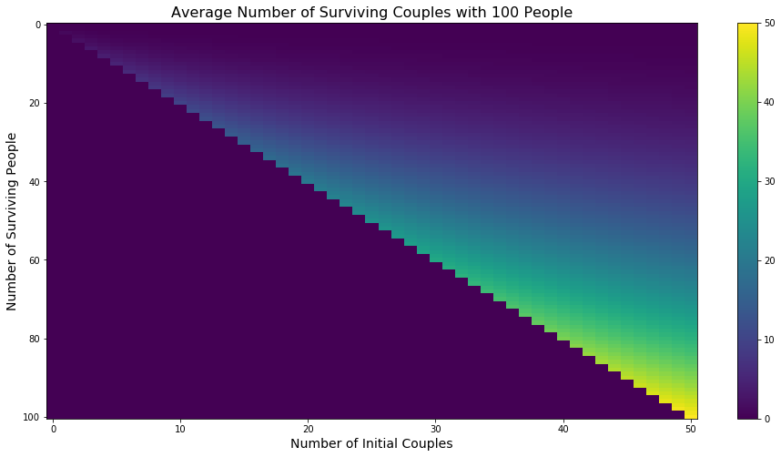

## Problem Set 4:

See 2010 Problem Set 4.

[output not shown]